# GBR coral mortality: formal BRMS-BRT prediction models

Blocked validation, cross-fitted stacking, and all-event production refits

# What was fitted

The response tables retain the established bleaching-attribution restriction: disturbance codes `b`, `m`, `n`, or an unrecorded disturbance are eligible, while records explicitly assigned to COTS, storms/cyclones, disease, or other excluded disturbances are not used. The meaning of `m` is unchanged, and blank disturbance records remain eligible when mortality can plausibly be attributed to the bleaching event. Genuine zero-loss observations are retained as controls.

The benchmark models remain interpretable references. They do not limit the production learners. The formal BRMS model is boundary-aware and hierarchical, with a nonlinear DHW response, all attainable environmental predictors, preceding-year Acropora proportion and absolute Acropora cover, a DHW–Acropora interaction, and prespecified DHW interactions with cloud, Secchi depth, current speed, prior severe heat exposure, ten-year cumulative heat load, signed thermal novelty, and an acute IMOS optical-extreme metric. Reef, event, and region effects capture repeated observations in the positive beta mean. Event and region effects are now also fitted in the zero-boundary component, where the earlier models most strongly underpredicted 2024 occurrence.

The BRT uses the same predictors in a two-part occurrence/magnitude model. Its positive component compares Gaussian mortality against a logit-Gaussian bounded response. Response scale, tree depth, learning rate, minimum node size, and tree number are selected only within each outer analysis fold.

All observations receive one out-of-fold prediction per validation scheme. Ensemble weights for a held-out fold are learned only from the other folds. Two ensembles are retained: a BRMS-BRT framework blend and a prediction-focused stack that may also use the low-variance benchmark. Final production weights use the event- and reef-blocked predictions; region blocking remains a geographic stress test. The final models are refitted on every modern event, including 2024.

Two prediction targets are kept explicit. Leave-one-event-out predictions are future-event forecasts and exclude event and region random effects. Reef-blocked predictions represent mapping an observed event to unsurveyed reefs and include the known event and region effects. Region-blocked predictions include the known event effect but exclude the held-out region effect. GBR-wide reconstruction should therefore be judged primarily from reef-blocked validation, while leave-one-event-out remains the stricter test of forecasting a new event.

## Pre-event Acropora reconstruction

Acropora composition is aligned to the survey used as the pre-bleaching coral cover baseline. Exact reef, depth, and baseline-year observations are preferred. Where these are unavailable, only past observations are used: first the same reef, then a past-only spatial-temporal interpolation. No future community composition is allowed to enter a validation row.

| Programme | Source | Rows | Coverage |
| --- | --- | --- | --- |
| LTMP benthic | Observed reef-depth-year | 199 | 100.0% |
| LTMP manta tow | Observed reef-depth-year | 173 | 69.8% |
| LTMP manta tow | Past-only spatial-temporal estimate | 58 | 23.4% |
| LTMP manta tow | Earlier observation at same reef | 17 | 6.9% |
| MMP inshore | Observed reef-depth-year | 88 | 97.8% |
| MMP inshore | Past-only spatial-temporal estimate | 2 | 2.2% |

All 537 validation observations now have a preceding-year Acropora estimate. The source year is checked to be no later than the baseline year. LTMP benthic is fully observed, MMP is 97.8% observed, and manta tow is 69.8% observed; the remaining manta estimates therefore deserve a source-specific sensitivity analysis before ecological effect sizes are treated as definitive.

# Blocked predictive performance

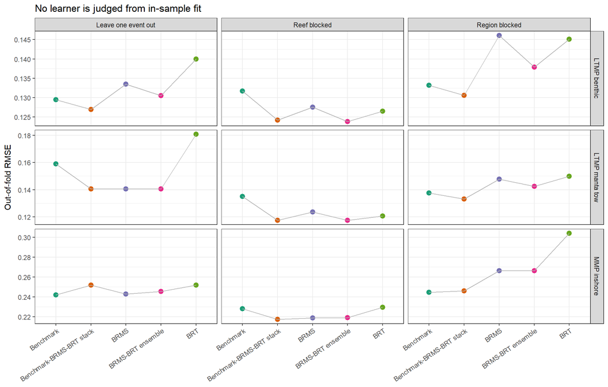

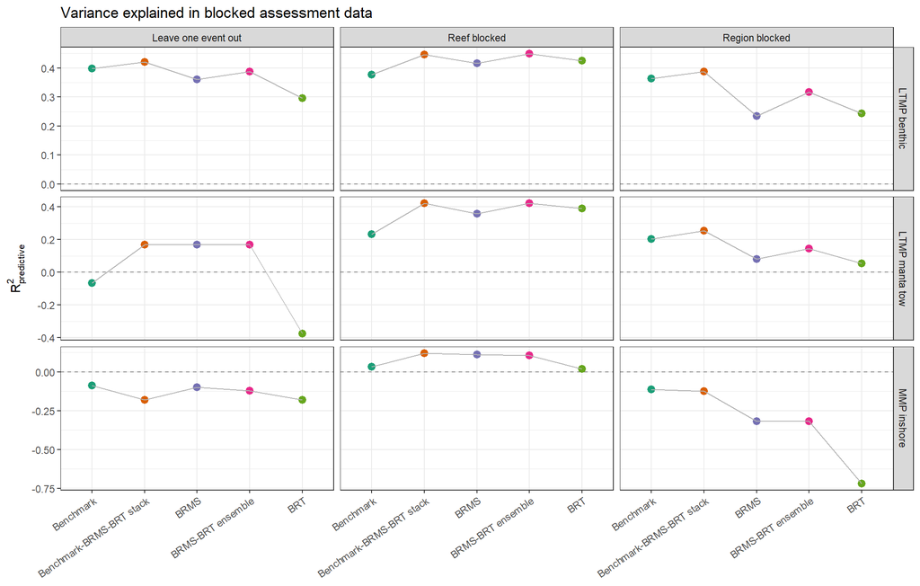

| Programme | Assessment | Learner | n | MAE | RMSE | Predictive R2 | Balanced MAE | Severe-event MAE | Occurrence Brier | Bias | Observed mean | Predicted mean |
| --- | --- | --- | --- | --- | --- | --- | --- | --- | --- | --- | --- | --- |
| LTMP benthic | Leave one event out | Benchmark-BRMS-BRT stack | 199 | 0.084 | 0.127 | 0.421 | 0.088 | 0.235 | 0.259 | -0.001 | 0.089 | 0.088 |
| LTMP benthic | Leave one event out | Benchmark | 199 | 0.085 | 0.130 | 0.397 | 0.089 | 0.241 | 0.280 | -0.004 | 0.089 | 0.084 |
| LTMP benthic | Leave one event out | BRMS-BRT ensemble | 199 | 0.085 | 0.131 | 0.388 | 0.088 | 0.234 | 0.247 | 0.000 | 0.089 | 0.089 |
| LTMP benthic | Leave one event out | BRMS | 199 | 0.089 | 0.133 | 0.360 | 0.092 | 0.220 | 0.244 | 0.010 | 0.089 | 0.099 |
| LTMP benthic | Leave one event out | BRT | 199 | 0.083 | 0.140 | 0.297 | 0.088 | 0.275 | 0.289 | -0.017 | 0.089 | 0.072 |
| LTMP benthic | Reef blocked | BRMS-BRT ensemble | 199 | 0.078 | 0.124 | 0.449 | 0.082 | 0.232 | 0.202 | -0.002 | 0.089 | 0.086 |
| LTMP benthic | Reef blocked | Benchmark-BRMS-BRT stack | 199 | 0.079 | 0.124 | 0.446 | 0.083 | 0.234 | 0.205 | -0.002 | 0.089 | 0.087 |
| LTMP benthic | Reef blocked | BRT | 199 | 0.081 | 0.127 | 0.425 | 0.085 | 0.232 | 0.213 | -0.003 | 0.089 | 0.086 |
| LTMP benthic | Reef blocked | BRMS | 199 | 0.077 | 0.128 | 0.416 | 0.081 | 0.238 | 0.205 | -0.001 | 0.089 | 0.087 |
| LTMP benthic | Reef blocked | Benchmark | 199 | 0.086 | 0.132 | 0.376 | 0.090 | 0.242 | 0.235 | 0.000 | 0.089 | 0.089 |
| LTMP benthic | Region blocked | Benchmark-BRMS-BRT stack | 199 | 0.090 | 0.131 | 0.387 | 0.092 | 0.214 | 0.239 | 0.022 | 0.089 | 0.110 |
| LTMP benthic | Region blocked | Benchmark | 199 | 0.090 | 0.133 | 0.363 | 0.093 | 0.238 | 0.246 | 0.009 | 0.089 | 0.097 |
| LTMP benthic | Region blocked | BRMS-BRT ensemble | 199 | 0.096 | 0.138 | 0.317 | 0.099 | 0.210 | 0.271 | 0.024 | 0.089 | 0.113 |
| LTMP benthic | Region blocked | BRT | 199 | 0.097 | 0.145 | 0.244 | 0.101 | 0.238 | 0.341 | 0.009 | 0.089 | 0.098 |
| LTMP benthic | Region blocked | BRMS | 199 | 0.106 | 0.146 | 0.234 | 0.108 | 0.202 | 0.220 | 0.043 | 0.089 | 0.131 |
| LTMP manta tow | Leave one event out | BRMS | 248 | 0.105 | 0.141 | 0.169 | 0.109 | 0.221 | 0.266 | -0.011 | 0.103 | 0.092 |
| LTMP manta tow | Leave one event out | BRMS-BRT ensemble | 248 | 0.105 | 0.141 | 0.169 | 0.109 | 0.221 | 0.266 | -0.011 | 0.103 | 0.092 |
| LTMP manta tow | Leave one event out | Benchmark-BRMS-BRT stack | 248 | 0.105 | 0.141 | 0.169 | 0.109 | 0.221 | 0.266 | -0.011 | 0.103 | 0.092 |
| LTMP manta tow | Leave one event out | Benchmark | 248 | 0.116 | 0.159 | -0.066 | 0.121 | 0.238 | 0.321 | -0.017 | 0.103 | 0.086 |
| LTMP manta tow | Leave one event out | BRT | 248 | 0.136 | 0.181 | -0.376 | 0.140 | 0.279 | 0.400 | -0.013 | 0.103 | 0.090 |
| LTMP manta tow | Reef blocked | BRMS-BRT ensemble | 248 | 0.084 | 0.117 | 0.420 | 0.088 | 0.170 | 0.176 | -0.003 | 0.103 | 0.100 |
| LTMP manta tow | Reef blocked | Benchmark-BRMS-BRT stack | 248 | 0.084 | 0.117 | 0.420 | 0.088 | 0.170 | 0.176 | -0.003 | 0.103 | 0.100 |
| LTMP manta tow | Reef blocked | BRT | 248 | 0.085 | 0.121 | 0.388 | 0.088 | 0.168 | 0.190 | -0.001 | 0.103 | 0.102 |
| LTMP manta tow | Reef blocked | BRMS | 248 | 0.087 | 0.124 | 0.356 | 0.091 | 0.179 | 0.182 | -0.006 | 0.103 | 0.097 |
| LTMP manta tow | Reef blocked | Benchmark | 248 | 0.103 | 0.135 | 0.231 | 0.106 | 0.190 | 0.223 | -0.001 | 0.103 | 0.102 |
| LTMP manta tow | Region blocked | Benchmark-BRMS-BRT stack | 248 | 0.103 | 0.133 | 0.254 | 0.106 | 0.192 | 0.209 | 0.005 | 0.103 | 0.108 |
| LTMP manta tow | Region blocked | Benchmark | 248 | 0.103 | 0.138 | 0.204 | 0.106 | 0.191 | 0.252 | -0.003 | 0.103 | 0.100 |
| LTMP manta tow | Region blocked | BRMS-BRT ensemble | 248 | 0.111 | 0.143 | 0.145 | 0.114 | 0.201 | 0.207 | 0.014 | 0.103 | 0.116 |
| LTMP manta tow | Region blocked | BRMS | 248 | 0.109 | 0.148 | 0.081 | 0.113 | 0.197 | 0.203 | 0.014 | 0.103 | 0.117 |
| LTMP manta tow | Region blocked | BRT | 248 | 0.116 | 0.150 | 0.053 | 0.119 | 0.209 | 0.254 | 0.011 | 0.103 | 0.114 |
| MMP inshore | Leave one event out | Benchmark | 90 | 0.171 | 0.242 | -0.088 | 0.160 | 0.254 | 0.208 | -0.026 | 0.187 | 0.161 |
| MMP inshore | Leave one event out | BRMS | 90 | 0.174 | 0.243 | -0.098 | 0.163 | 0.288 | 0.355 | -0.053 | 0.187 | 0.134 |
| MMP inshore | Leave one event out | BRMS-BRT ensemble | 90 | 0.174 | 0.246 | -0.121 | 0.163 | 0.297 | 0.320 | -0.060 | 0.187 | 0.128 |
| MMP inshore | Leave one event out | Benchmark-BRMS-BRT stack | 90 | 0.182 | 0.252 | -0.180 | 0.171 | 0.283 | 0.262 | -0.034 | 0.187 | 0.153 |
| MMP inshore | Leave one event out | BRT | 90 | 0.176 | 0.252 | -0.181 | 0.161 | 0.319 | 0.302 | -0.078 | 0.187 | 0.110 |
| MMP inshore | Reef blocked | Benchmark-BRMS-BRT stack | 90 | 0.162 | 0.217 | 0.121 | 0.159 | 0.202 | 0.190 | 0.017 | 0.187 | 0.205 |
| MMP inshore | Reef blocked | BRMS | 90 | 0.158 | 0.219 | 0.110 | 0.154 | 0.200 | 0.190 | 0.019 | 0.187 | 0.206 |
| MMP inshore | Reef blocked | BRMS-BRT ensemble | 90 | 0.158 | 0.219 | 0.106 | 0.153 | 0.202 | 0.187 | 0.015 | 0.187 | 0.202 |
| MMP inshore | Reef blocked | Benchmark | 90 | 0.168 | 0.228 | 0.033 | 0.165 | 0.218 | 0.206 | 0.000 | 0.187 | 0.187 |
| MMP inshore | Reef blocked | BRT | 90 | 0.159 | 0.230 | 0.019 | 0.149 | 0.228 | 0.198 | -0.012 | 0.187 | 0.175 |
| MMP inshore | Region blocked | Benchmark | 90 | 0.186 | 0.245 | -0.113 | 0.181 | 0.258 | 0.243 | -0.011 | 0.187 | 0.177 |
| MMP inshore | Region blocked | Benchmark-BRMS-BRT stack | 90 | 0.187 | 0.246 | -0.125 | 0.182 | 0.262 | 0.250 | -0.012 | 0.187 | 0.175 |
| MMP inshore | Region blocked | BRMS | 90 | 0.226 | 0.266 | -0.318 | 0.237 | 0.231 | 0.291 | 0.055 | 0.187 | 0.243 |
| MMP inshore | Region blocked | BRMS-BRT ensemble | 90 | 0.226 | 0.266 | -0.318 | 0.237 | 0.231 | 0.291 | 0.055 | 0.187 | 0.243 |
| MMP inshore | Region blocked | BRT | 90 | 0.259 | 0.304 | -0.720 | 0.268 | 0.271 | 0.412 | 0.058 | 0.187 | 0.245 |

## Current predictive choice

The table below pools the two prespecified selection tasks: transfer to another event and transfer to unsurveyed reefs. It is an honest routing decision, not a claim that the winning learner is the most ecologically informative model.

| Programme | Learner | n | MAE | RMSE | Predictive R2 | Balanced MAE | Severe-event MAE | Occurrence Brier | Bias |
| --- | --- | --- | --- | --- | --- | --- | --- | --- | --- |
| LTMP benthic | Benchmark-BRMS-BRT stack | 398 | 0.082 | 0.126 | 0.433 | 0.085 | 0.234 | 0.232 | -0.001 |
| LTMP manta tow | BRMS-BRT ensemble | 496 | 0.095 | 0.129 | 0.294 | 0.099 | 0.195 | 0.221 | -0.007 |
| MMP inshore | BRMS-BRT ensemble | 180 | 0.166 | 0.233 | -0.008 | 0.158 | 0.250 | 0.254 | -0.022 |

RMSE remains the primary measure for the continuous expected-mortality target: it penalises large errors in the high-mortality observations that matter most for GBR-wide loss estimates. It is not sufficient alone for this zero-heavy response. Balanced MAE gives zero and positive observations equal influence, severe-event MAE targets observations with at least 20% mortality, and the occurrence Brier score assesses the boundary component.

LTMP and manta select the displayed routes consistently across the continuous error measures. MMP is less decisive: BRMS has the lowest pooled RMSE (0.231), but the BRMS–BRT ensemble is within 1%, improves balanced MAE and occurrence Brier score, and retains both modelling frameworks. It is therefore the provisional MMP production route. This explicit trade-off is preferable to declaring a DHW-only benchmark the winner from one metric in a small, three-event dataset.

# Event context added in this refit

Ten-year cumulative load is the sum of annual DHW above 4 within the ten full calendar years before an event. Signed novelty is current annual maximum DHW minus the greatest annual maximum in that preceding window. Negative values therefore identify events weaker than recent exposure, while positive values identify unprecedented exposure. The acute optical predictor is `1.7 / Q90(Kd490)` during January–March: lower values indicate unusually low water clarity. It is a consistent IMOS plume/turbidity proxy, not a direct salinity measurement.

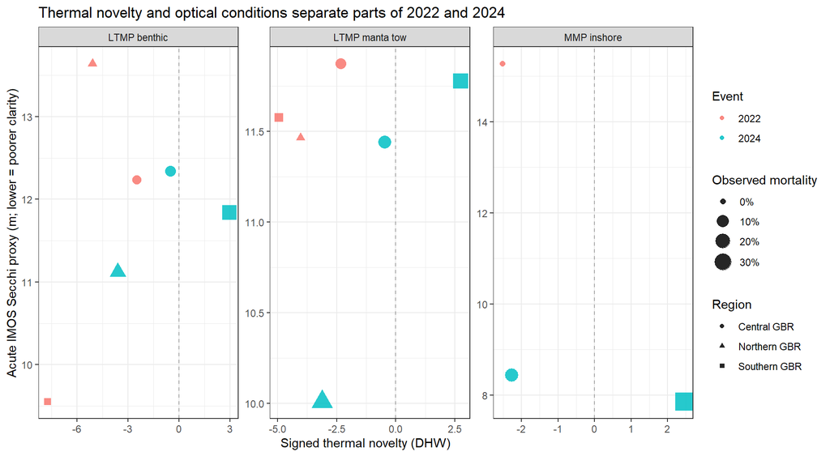

# Forecasting and reconstructing the 2024 event

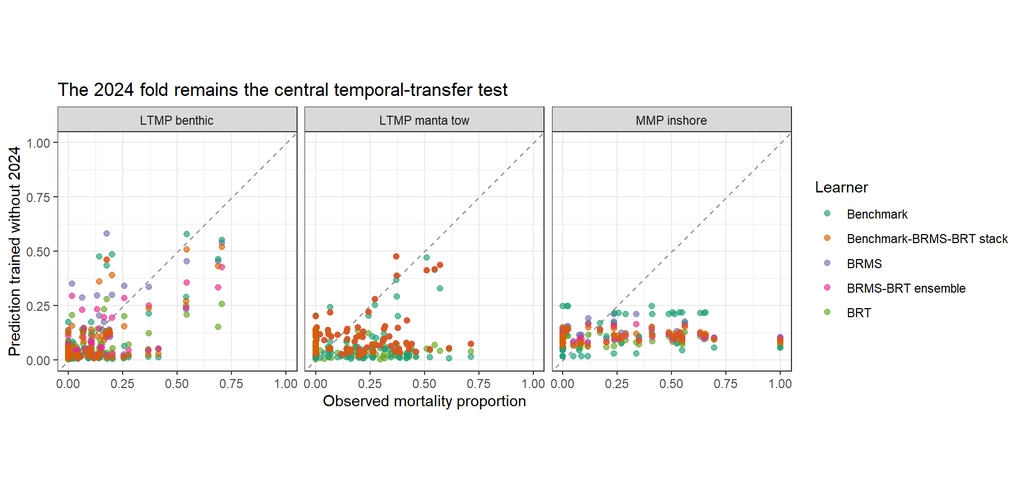

| Programme | Learner | n | Observed mean | Predicted mean | Bias | RMSE | Predictive R2 | Balanced MAE |
| --- | --- | --- | --- | --- | --- | --- | --- | --- |
| LTMP benthic | Benchmark-BRMS-BRT stack | 75 | 0.113 | 0.086 | -0.026 | 0.117 | 0.439 | 0.071 |
| LTMP benthic | BRMS-BRT ensemble | 75 | 0.113 | 0.089 | -0.024 | 0.121 | 0.394 | 0.075 |
| LTMP benthic | BRMS | 75 | 0.113 | 0.101 | -0.012 | 0.125 | 0.359 | 0.077 |
| LTMP benthic | Benchmark | 75 | 0.113 | 0.082 | -0.031 | 0.125 | 0.354 | 0.074 |
| LTMP benthic | BRT | 75 | 0.113 | 0.071 | -0.042 | 0.136 | 0.243 | 0.079 |
| LTMP manta tow | BRMS | 89 | 0.191 | 0.107 | -0.084 | 0.195 | -0.185 | 0.129 |
| LTMP manta tow | BRMS-BRT ensemble | 89 | 0.191 | 0.107 | -0.084 | 0.195 | -0.185 | 0.129 |
| LTMP manta tow | Benchmark-BRMS-BRT stack | 89 | 0.191 | 0.107 | -0.084 | 0.195 | -0.185 | 0.129 |
| LTMP manta tow | Benchmark | 89 | 0.191 | 0.068 | -0.123 | 0.214 | -0.432 | 0.121 |
| LTMP manta tow | BRT | 89 | 0.191 | 0.038 | -0.153 | 0.237 | -0.756 | 0.133 |
| MMP inshore | Benchmark | 54 | 0.238 | 0.119 | -0.119 | 0.286 | -0.104 | 0.166 |
| MMP inshore | BRMS | 54 | 0.238 | 0.121 | -0.116 | 0.297 | -0.191 | 0.190 |
| MMP inshore | Benchmark-BRMS-BRT stack | 54 | 0.238 | 0.105 | -0.133 | 0.300 | -0.213 | 0.184 |
| MMP inshore | BRMS-BRT ensemble | 54 | 0.238 | 0.110 | -0.128 | 0.300 | -0.219 | 0.188 |
| MMP inshore | BRT | 54 | 0.238 | 0.090 | -0.148 | 0.309 | -0.287 | 0.187 |

## Component calibration in 2022 and 2024

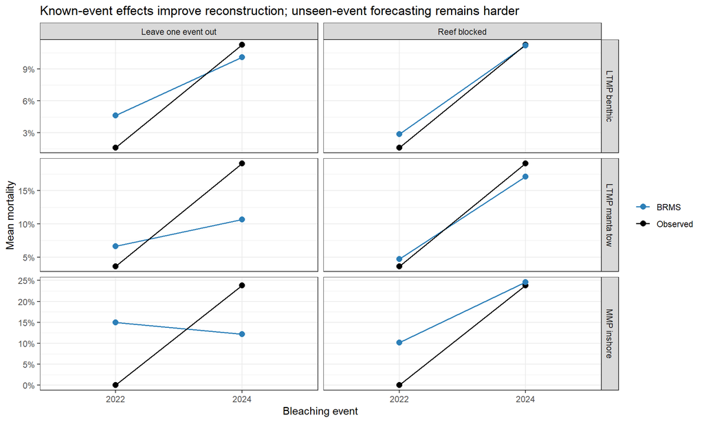

| Programme | Assessment | Event | n | Observed mean | Predicted mean | Observed occurrence | Predicted occurrence | Observed positive magnitude | Predicted positive magnitude |
| --- | --- | --- | --- | --- | --- | --- | --- | --- | --- |
| LTMP benthic | Leave one event out | 2022 | 36 | 0.016 | 0.046 | 0.361 | 0.248 | 0.044 | 0.190 |
| LTMP benthic | Leave one event out | 2024 | 75 | 0.113 | 0.101 | 0.627 | 0.431 | 0.180 | 0.245 |
| LTMP benthic | Reef blocked | 2022 | 36 | 0.016 | 0.029 | 0.361 | 0.321 | 0.044 | 0.106 |
| LTMP benthic | Reef blocked | 2024 | 75 | 0.113 | 0.112 | 0.627 | 0.603 | 0.180 | 0.191 |
| LTMP manta tow | Leave one event out | 2022 | 53 | 0.036 | 0.067 | 0.302 | 0.267 | 0.119 | 0.276 |
| LTMP manta tow | Leave one event out | 2024 | 89 | 0.191 | 0.107 | 0.730 | 0.480 | 0.262 | 0.224 |
| LTMP manta tow | Reef blocked | 2022 | 53 | 0.036 | 0.047 | 0.302 | 0.297 | 0.119 | 0.168 |
| LTMP manta tow | Reef blocked | 2024 | 89 | 0.191 | 0.171 | 0.730 | 0.717 | 0.262 | 0.245 |
| MMP inshore | Leave one event out | 2022 | 4 | 0.000 | 0.150 | 0.000 | 0.715 | NA | NA |
| MMP inshore | Leave one event out | 2024 | 54 | 0.238 | 0.121 | 0.667 | 0.267 | 0.357 | 0.655 |
| MMP inshore | Reef blocked | 2022 | 4 | 0.000 | 0.102 | 0.000 | 0.355 | NA | NA |
| MMP inshore | Reef blocked | 2024 | 54 | 0.238 | 0.246 | 0.667 | 0.638 | 0.357 | 0.404 |

For known-event reef-blocked reconstruction, BRMS reproduces 2024 mean mortality closely: 0.112 versus 0.113 observed for LTMP benthic, 0.171 versus 0.191 for manta tow, and 0.246 versus 0.238 for MMP. Occurrence is also close. Leave-one-event-out forecasting remains more conservative, particularly for MMP. The 2022 positive magnitude is still overpredicted by BRMS, although the known-event effect reduces the error. This residual is an explicit target for future event-mechanism work, not a reason to discard the bounded beta response.

# Ensemble weights

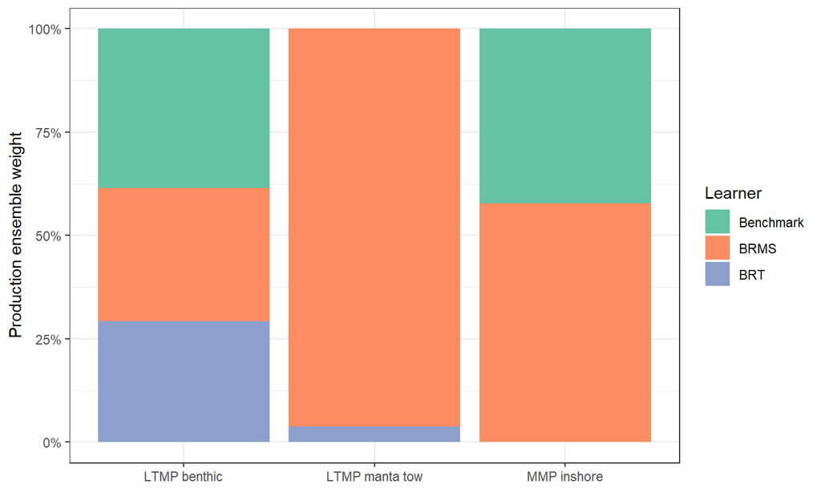

The weights are performance estimates, not ecological importance measures. A weight near zero means that one learner did not add squared-error skill to the other under the current blocked data; it does not invalidate that framework’s uncertainty estimates or mechanistic interpretation.

| Programme | Ensemble | Cross-fitted predictions | Benchmark | BRMS | BRT |
| --- | --- | --- | --- | --- | --- |
| LTMP benthic | BRMS-BRT ensemble | 398 | 0.000 | 0.571 | 0.429 |
| LTMP benthic | Benchmark-BRMS-BRT stack | 398 | 0.385 | 0.322 | 0.293 |
| LTMP manta tow | BRMS-BRT ensemble | 496 | 0.000 | 0.962 | 0.038 |
| LTMP manta tow | Benchmark-BRMS-BRT stack | 496 | 0.000 | 0.962 | 0.038 |
| MMP inshore | BRMS-BRT ensemble | 180 | 0.000 | 1.000 | 0.000 |
| MMP inshore | Benchmark-BRMS-BRT stack | 180 | 0.422 | 0.578 | 0.000 |

# Predictive influence

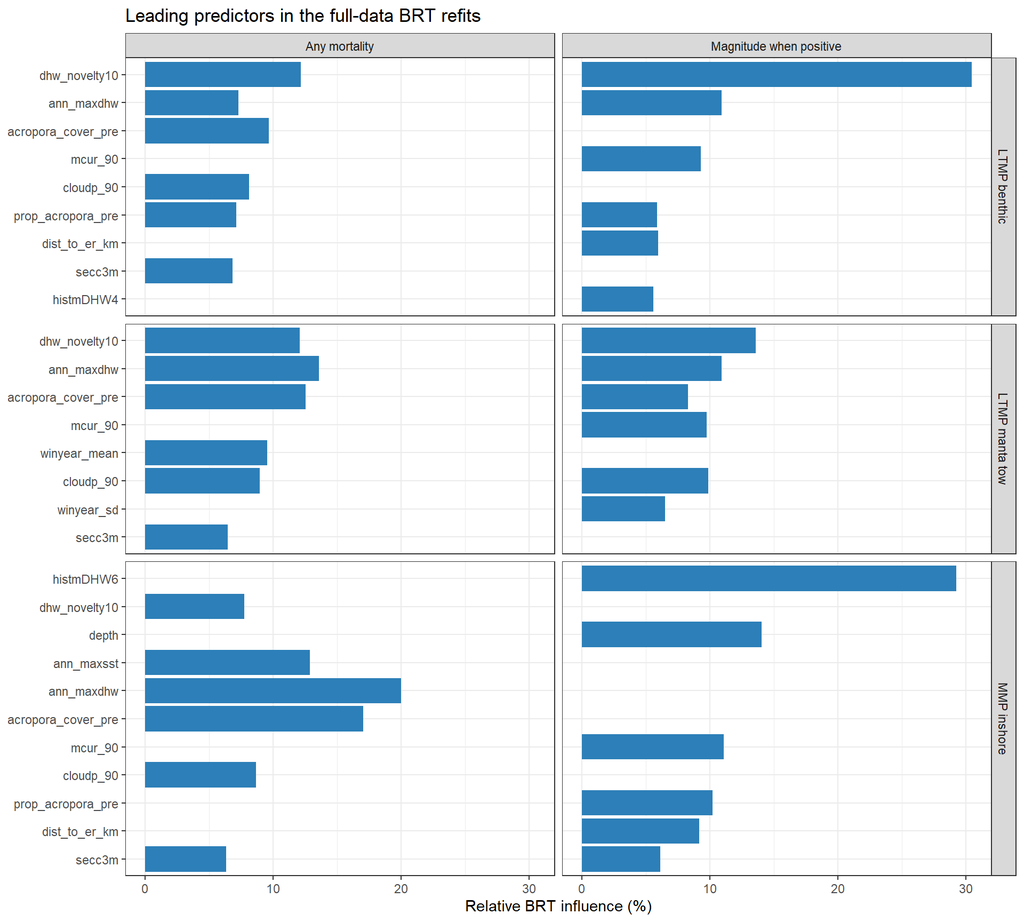

BRT influence measures predictive use, not causal effect or effect direction. Correlated thermal-history variables can share or exchange influence. The BRMS model therefore remains the appropriate framework for response-shape and uncertainty summaries, while blocked predictions decide production routing.

# Ecological explanatory fit

Predictive validation and ecological explanation answer different questions. For the nested two-part GLM benchmarks, AICc and McFadden pseudo-R2 are reported for the binomial occurrence component. The positive-magnitude component is quasibinomial, so it has no likelihood-based AIC; its deviance explained is shown instead. The apparent response R2 is an in-sample descriptive statistic, not an estimate of transfer skill.

| Programme | Model | Occurrence AICc | Occurrence McFadden R2 | Positive deviance explained | Apparent response R2 |
| --- | --- | --- | --- | --- | --- |
| LTMP benthic | DHW + context + Acropora | 251.523 | 0.164 | 0.504 | 0.461 |
| LTMP benthic | DHW + physical context | 259.525 | 0.110 | 0.492 | 0.465 |
| LTMP benthic | Nonlinear DHW | 262.681 | 0.067 | 0.299 | 0.336 |
| LTMP benthic | Linear DHW | 264.804 | 0.044 | 0.228 | 0.237 |
| LTMP benthic | Nonlinear DHW + optics | 265.155 | 0.073 | 0.363 | 0.376 |
| LTMP manta tow | DHW + context + Acropora | 311.013 | 0.155 | 0.295 | 0.335 |
| LTMP manta tow | DHW + physical context | 317.385 | 0.117 | 0.254 | 0.273 |
| LTMP manta tow | Linear DHW | 318.227 | 0.078 | 0.093 | 0.162 |
| LTMP manta tow | Nonlinear DHW | 318.795 | 0.088 | 0.114 | 0.180 |
| LTMP manta tow | Nonlinear DHW + optics | 322.698 | 0.089 | 0.177 | 0.182 |
| MMP inshore | Linear DHW | 109.034 | 0.095 | 0.024 | 0.093 |
| MMP inshore | Nonlinear DHW | 110.121 | 0.123 | 0.083 | 0.081 |
| MMP inshore | DHW + context + Acropora | 110.565 | 0.265 | 0.440 | 0.435 |
| MMP inshore | Nonlinear DHW + optics | 111.665 | 0.149 | 0.215 | 0.176 |
| MMP inshore | DHW + physical context | 114.752 | 0.163 | 0.295 | 0.285 |

| Programme | Component | Predictor | Relative influence (%) |
| --- | --- | --- | --- |
| LTMP benthic | Any mortality | Pre-event absolute Acropora cover | 9.67 |
| LTMP benthic | Any mortality | Pre-event Acropora proportion | 7.14 |
| LTMP benthic | Magnitude when positive | Pre-event Acropora proportion | 5.87 |
| LTMP benthic | Magnitude when positive | Pre-event absolute Acropora cover | 3.32 |
| LTMP manta tow | Any mortality | Pre-event absolute Acropora cover | 12.55 |
| LTMP manta tow | Any mortality | Pre-event Acropora proportion | 3.76 |
| LTMP manta tow | Magnitude when positive | Pre-event absolute Acropora cover | 8.29 |
| LTMP manta tow | Magnitude when positive | Pre-event Acropora proportion | 4.85 |
| MMP inshore | Any mortality | Pre-event absolute Acropora cover | 17.05 |
| MMP inshore | Any mortality | Pre-event Acropora proportion | 3.24 |
| MMP inshore | Magnitude when positive | Pre-event Acropora proportion | 10.22 |
| MMP inshore | Magnitude when positive | Pre-event absolute Acropora cover | 3.78 |

Both Acropora measures are used by both BRT components. Absolute pre-event Acropora cover is particularly influential for occurrence in manta tow and MMP. Relative influence is predictive usage rather than a causal effect, and the two correlated composition measures may divide influence between them.

| Programme | Marginal Bayesian R2 | Marginal R2 90% lower | Marginal R2 90% upper | Conditional Bayesian R2 | LOOIC | Pareto k > 0.7 | Maximum Pareto k |
| --- | --- | --- | --- | --- | --- | --- | --- |
| LTMP benthic | 0.447 | 0.253 | 0.583 | 0.518 | 101.315 | 16 | 1.097 |
| LTMP manta tow | 0.215 | 0.077 | 0.360 | 0.461 | 147.941 | 10 | 1.086 |
| MMP inshore | 0.284 | 0.071 | 0.507 | 0.387 | 47.252 | 7 | 0.870 |

Marginal Bayesian R2 describes the variance captured by the population-level environmental response; conditional Bayesian R2 also includes reef, event, and region effects. LOOIC is reported for completeness but is not used to compare programmes or route predictions. Each production fit has influential observations with Pareto k above 0.7, so these raw LOO values require moment matching or exact refits before they can support fine model comparisons.

AIC, LOOIC, and R2 are not interchangeable across the GLM, BRT, and BRMS frameworks. The models use different likelihoods and boundary constructions. Blocked scores on identical assessment rows remain the valid cross-framework comparison; model-family-specific fit statistics support interpretation within each framework.

# Diagnostics

| Programme | Assessment | Folds | Maximum R-hat | Minimum bulk ESS | Minimum tail ESS | Divergences | Tree-depth hits | Passing folds |
| --- | --- | --- | --- | --- | --- | --- | --- | --- |
| LTMP benthic | Leave one event out | 5 | 1.01 | 303.05 | 319.22 | 0 | 0 | 5 |
| LTMP benthic | Reef blocked | 5 | 1.01 | 201.84 | 498.54 | 0 | 0 | 5 |
| LTMP benthic | Region blocked | 3 | 1.01 | 452.97 | 730.61 | 0 | 0 | 3 |
| LTMP manta tow | Leave one event out | 5 | 1.01 | 239.15 | 446.79 | 0 | 0 | 5 |
| LTMP manta tow | Reef blocked | 5 | 1.01 | 298.59 | 365.16 | 0 | 0 | 5 |
| LTMP manta tow | Region blocked | 3 | 1.01 | 166.71 | 300.91 | 0 | 0 | 3 |
| MMP inshore | Leave one event out | 3 | 1.01 | 632.69 | 782.09 | 0 | 0 | 3 |
| MMP inshore | Reef blocked | 5 | 1.01 | 520.20 | 617.39 | 0 | 0 | 5 |
| MMP inshore | Region blocked | 2 | 1.01 | 657.47 | 774.33 | 0 | 0 | 2 |

[output not shown]

All 36 outer BRMS fits pass the prespecified diagnostic gate: maximum R-hat 1.01, minimum bulk ESS 167, minimum tail ESS 301, zero divergences, and zero maximum-tree-depth hits. All three longer production fits also pass.

| Programme | Assessment | interaction_depth | shrinkage | minobs | magnitude_mode | n_trees | Outer folds selecting setting |
| --- | --- | --- | --- | --- | --- | --- | --- |
| LTMP benthic | Leave one event out | 1 | 0.01 | 5 | gaussian | 500 | 1 |
| LTMP benthic | Leave one event out | 2 | 0.03 | 5 | logit_gaussian | 1500 | 1 |
| LTMP benthic | Leave one event out | 3 | 0.03 | 5 | gaussian | 250 | 1 |
| LTMP benthic | Leave one event out | 3 | 0.03 | 5 | logit_gaussian | 250 | 1 |
| LTMP benthic | Leave one event out | 3 | 0.03 | 5 | logit_gaussian | 1500 | 1 |
| LTMP benthic | Reef blocked | 1 | 0.01 | 5 | gaussian | 500 | 2 |
| LTMP benthic | Reef blocked | 2 | 0.01 | 5 | gaussian | 1000 | 1 |
| LTMP benthic | Reef blocked | 3 | 0.01 | 5 | gaussian | 250 | 1 |
| LTMP benthic | Reef blocked | 3 | 0.03 | 5 | gaussian | 100 | 1 |
| LTMP benthic | Region blocked | 2 | 0.03 | 5 | gaussian | 250 | 1 |
| LTMP benthic | Region blocked | 2 | 0.03 | 5 | logit_gaussian | 1500 | 1 |
| LTMP benthic | Region blocked | 3 | 0.01 | 5 | logit_gaussian | 1000 | 1 |
| LTMP manta tow | Leave one event out | 3 | 0.03 | 10 | gaussian | 250 | 2 |
| LTMP manta tow | Leave one event out | 2 | 0.01 | 5 | gaussian | 1000 | 1 |
| LTMP manta tow | Leave one event out | 2 | 0.03 | 5 | gaussian | 250 | 1 |
| LTMP manta tow | Leave one event out | 3 | 0.01 | 5 | gaussian | 500 | 1 |
| LTMP manta tow | Reef blocked | 2 | 0.03 | 5 | gaussian | 250 | 1 |
| LTMP manta tow | Reef blocked | 3 | 0.01 | 5 | gaussian | 1000 | 1 |
| LTMP manta tow | Reef blocked | 3 | 0.01 | 5 | gaussian | 1500 | 1 |
| LTMP manta tow | Reef blocked | 3 | 0.01 | 10 | gaussian | 1500 | 1 |
| LTMP manta tow | Reef blocked | 3 | 0.03 | 10 | gaussian | 500 | 1 |
| LTMP manta tow | Region blocked | 2 | 0.01 | 5 | gaussian | 1000 | 1 |
| LTMP manta tow | Region blocked | 2 | 0.03 | 5 | gaussian | 500 | 1 |
| LTMP manta tow | Region blocked | 3 | 0.01 | 5 | gaussian | 500 | 1 |
| MMP inshore | Leave one event out | 2 | 0.01 | 10 | gaussian | 100 | 1 |
| MMP inshore | Leave one event out | 2 | 0.03 | 10 | gaussian | 100 | 1 |
| MMP inshore | Leave one event out | 3 | 0.01 | 10 | gaussian | 100 | 1 |
| MMP inshore | Reef blocked | 3 | 0.01 | 10 | gaussian | 100 | 2 |
| MMP inshore | Reef blocked | 2 | 0.01 | 5 | logit_gaussian | 500 | 1 |
| MMP inshore | Reef blocked | 2 | 0.03 | 10 | gaussian | 250 | 1 |
| MMP inshore | Reef blocked | 3 | 0.03 | 10 | gaussian | 500 | 1 |
| MMP inshore | Region blocked | 1 | 0.01 | 10 | gaussian | 100 | 1 |
| MMP inshore | Region blocked | 3 | 0.01 | 10 | gaussian | 1500 | 1 |

# Interpretation and next use

The formal comparison answers a predictive question: how well can each learner transfer to another bleaching event, another set of reefs, or another GBR region? Coefficients and variable influence are secondary and must be read in the context of correlated predictors. GBR-wide application should generate predictions from every saved full-data component and then apply the validated programme-specific route shown above. Environmental-novelty flags are still required for extrapolation checks even though signed novelty is now a fitted predictor, and BRT resampling uncertainty should be propagated alongside the BRMS posterior before publication.

IMOS MODIS-Aqua Kd490 is used consistently as the water-clarity source. It is preferred to the modelled eReefs chlorophyll/Kd490 field for this application and provides the required 2024 coverage. Recovered nearshore Secchi estimates retain their extraction radius and observation counts for sensitivity checks. The new acute optical metric uses the Q1 Kd490 90th percentile from the same source and extraction geometry; it should not be labelled freshwater exposure without independent salinity validation.